# FIRMS

Fire Information for Resource Management System

## Overview

The FIRMS module provides access to NASA’s Fire Information for Resource Management System. FIRMS distributes near real-time active fire data from satellite sensors including MODIS, VIIRS, and LANDSAT.

**Data Source:** [NASA FIRMS](https://firms.modaps.eosdis.nasa.gov/)

## API Key Setup

FIRMS requires a free API key (MAP_KEY) from NASA.

1. Register at [NASA Earthdata](https://urs.earthdata.nasa.gov/users/new)
2. Request a FIRMS MAP_KEY at [FIRMS MAP_KEY Request](https://firms.modaps.eosdis.nasa.gov/api/area/)

```julia
using WildfireData

# Set via environment variable (recommended)
ENV["FIRMS_MAP_KEY"] = "your-32-character-key"

# Or set programmatically
FIRMS.set_map_key!("your-32-character-key")

# Check current key
FIRMS.get_map_key()
```

## Available Sources

| Source | Description |
| --- | --- |
| `:MODIS_NRT` | MODIS Near Real-Time |
| `:MODIS_SP` | MODIS Standard Processing |
| `:VIIRS_NOAA20_NRT` | VIIRS NOAA-20 Near Real-Time |
| `:VIIRS_NOAA21_NRT` | VIIRS NOAA-21 Near Real-Time |
| `:VIIRS_SNPP_NRT` | VIIRS Suomi NPP Near Real-Time |
| `:VIIRS_NOAA20_SP` | VIIRS NOAA-20 Standard Processing |
| `:VIIRS_SNPP_SP` | VIIRS Suomi NPP Standard Processing |
| `:LANDSAT_NRT` | LANDSAT Near Real-Time |

## Basic Usage

```julia
using WildfireData

# List all sources
FIRMS.sources()

# Filter by type
FIRMS.sources(type=:NRT)

# Print general info
FIRMS.info()
```

## Downloading Data

### By Region

```julia
# Download for a predefined region
df = FIRMS.download(:VIIRS_NOAA20_NRT, region=:california, days=1)

# Available regions
FIRMS.regions()  # :conus, :california, :western_us, etc.
```

### By Bounding Box

```julia
# Download for custom bounding box ("west,south,east,north")
df = FIRMS.download(:VIIRS_NOAA20_NRT, area="-125,32,-114,42", days=1)
```

### Historical Data

```julia
# Last N days (1-10)
df = FIRMS.download(:VIIRS_NOAA20_NRT, region=:california, days=3)

# Specific date
df = FIRMS.download(:VIIRS_SNPP_SP, region=:western_us, days=1, date="2023-08-15")
```

## Working with Results

FIRMS returns a DataFrame:

```julia
df = FIRMS.download(:VIIRS_NOAA20_NRT, region=:california, days=1)

# View columns
names(df)

# Filter by confidence
high_confidence = filter(row -> row.confidence == "h", df)

# Get fire locations
for row in eachrow(df)
    println("Lat: $(row.latitude), Lon: $(row.longitude)")
    println("  FRP: $(row.frp)")
end
```

## Key Fields

| Field | Description |
| --- | --- |
| `latitude` / `longitude` | Fire location |
| `bright_ti4` | Brightness temperature (Kelvin) |
| `bright_ti5` | Brightness temperature (Kelvin) |
| `frp` | Fire Radiative Power (MW) |
| `confidence` | Detection confidence (l/n/h for low/nominal/high) |
| `acq_date` | Acquisition date |
| `acq_time` | Acquisition time (HHMM) |
| `satellite` | Satellite name |
| `daynight` | Day or night detection (D/N) |

## Convenience Functions

```julia
# Get recent fires with optional confidence filtering
df = FIRMS.recent_fires(region=:california, days=2)
df = FIRMS.recent_fires(source=:MODIS_NRT, region=:conus, min_confidence=80)

# Group detections by date
by_date = FIRMS.hotspots_by_date(region=:western_us, days=5)

# Check data availability
avail = FIRMS.data_availability(:VIIRS_NOAA20_NRT)
```

## Saving and Loading Files

```julia
# Download and save to CSV
path = FIRMS.download_file(:VIIRS_NOAA20_NRT, region=:california, days=1)

# Load previously downloaded file (pass the filename as a String)
df = FIRMS.load_file("VIIRS_NOAA20_NRT_20240115.csv")
```

## Predefined Regions

```julia
FIRMS.regions()
```

| Region | Description |
| --- | --- |
| `:world` | Global coverage |
| `:conus` | Continental United States |
| `:alaska` | Alaska |
| `:california` | California |
| `:western_us` | Western United States |
| `:eastern_us` | Eastern United States |
| `:canada` | Canada |
| `:australia` | Australia |
| `:europe` | Europe |
| `:amazon` | Amazon basin |
| `:africa` | Africa |

## Plot Example

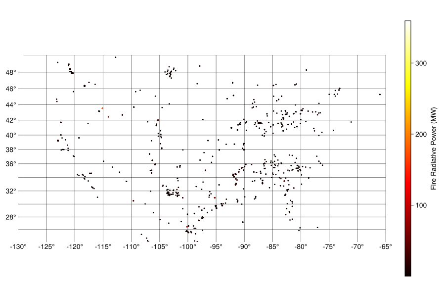

```julia
using WildfireData
using CairoMakie, GeoMakie, Tyler
using Extents, TileProviders
CairoMakie.activate!()

if !isempty(get(ENV, "FIRMS_MAP_KEY", ""))
    df = FIRMS.download(:VIIRS_NOAA20_NRT, region=:conus, days=1, verbose=false)

    if !isempty(df)
        ext = Extent(; X=(-130.0, -65.0), Y=(24.0, 50.0))
        m = Tyler.Map(ext;
            size = (900, 600),
            axis = (; type = GeoMakie.GeoAxis, dest = "+proj=merc"),
            provider = TileProviders.OpenStreetMap(:Mapnik),
        )
        sc = scatter!(m.axis, df.longitude, df.latitude, color=df.frp,
            colormap=:hot, markersize=4)
        Colorbar(m.figure[1, 2], sc, label="Fire Radiative Power (MW)")
        m.figure
    end
else
    @info "FIRMS_MAP_KEY not set, skipping plot"
end
```

## API Reference

### Functions

- `sources(; type=nothing)` - List available satellite sources
- `info()` - Print FIRMS API information
- `regions()` - List predefined regions
- `download(source; area, region, days, date, verbose)` - Download fire data
- `download_file(source; filename, force, verbose, ...)` - Download and save to file
- `load_file(filename)` - Load previously downloaded CSV file
- `query_url(source, area, days; date)` - Build API query URL
- `data_availability(source)` - Check data availability
- `recent_fires(; source, region, days, min_confidence)` - Get recent detections
- `hotspots_by_date(; source, region, days)` - Group detections by date
- `get_map_key()` - Get current API key
- `set_map_key!(key)` - Set API key
- `dir()` - Get local data directory path